# R Packages

Lecture 05

Dr. Colin Rundel

## What are R packages?

R packages are just collections of files - R code, compiled code (C, C++, Rust etc.), data, documentation, and others that live in your library path.

```r
.libPaths()
```

```
[1] "/Users/rundel/Library/R/arm64/4.5/library"
[2] "/Library/Frameworks/R.framework/Versions/4.5-arm64/Resources/library"
```

```r
dir(.libPaths())
```

```
  [1] "_backup"
  [2] "_build"
  [3] "_cache"
  [4] "abind"
  [5] "airports"
  [6] "and"
  [7] "anytime"
  [8] "ape"
  [9] "archive"
 [10] "arrayhelpers"
 [11] "arrow"
 [12] "AsioHeaders"
 [13] "askpass"
 [14] "assertthat"
 [15] "astsa"
```

[output cut: 782 more lines]

## Search path

To load a package we use `library(pkg)` which attachs the package’s namespace (functions, data, etc.) to the global search path.

```r
search()
```

```
[1] ".GlobalEnv"        "package:stats"
[3] "package:graphics"  "package:grDevices"
[5] "package:utils"     "package:datasets"
[7] "package:methods"   "Autoloads"
[9] "package:base"
```

```r
library(diffmatchpatch)
```

```r
search()
```

```
 [1] ".GlobalEnv"
 [2] "package:diffmatchpatch"
 [3] "package:stats"
 [4] "package:graphics"
 [5] "package:grDevices"
 [6] "package:utils"
 [7] "package:datasets"
 [8] "package:methods"
 [9] "Autoloads"
[10] "package:base"
```

## Loading vs attaching

If you do not want to attach a package you can directly *load* the package with `requireNamespace()`.

```r
loadedNamespaces()
```

```
 [1] "compiler"       "fastmap"
 [3] "cli"            "graphics"
 [5] "diffmatchpatch" "tools"
 [7] "htmltools"      "otel"
 [9] "utils"          "yaml"
[11] "grDevices"      "Rcpp"
[13] "stats"          "datasets"
[15] "rmarkdown"      "knitr"
[17] "methods"        "jsonlite"
[19] "xfun"           "digest"
[21] "rlang"          "base"
[23] "evaluate"
```

```r
requireNamespace("forcats")
loadedNamespaces()
```

```
 [1] "digest"         "methods"
 [3] "diffmatchpatch" "fastmap"
 [5] "xfun"           "magrittr"
 [7] "glue"           "knitr"
 [9] "htmltools"      "rmarkdown"
[11] "lifecycle"      "utils"
[13] "cli"            "graphics"
[15] "grDevices"      "stats"
[17] "compiler"       "forcats"
[19] "base"           "tools"
[21] "evaluate"       "Rcpp"
[23] "yaml"           "otel"
[25] "rlang"          "jsonlite"
[27] "datasets"
```

```r
search()
```

```
 [1] ".GlobalEnv"
 [2] "package:diffmatchpatch"
 [3] "package:stats"
 [4] "package:graphics"
 [5] "package:grDevices"
 [6] "package:utils"
 [7] "package:datasets"
 [8] "package:methods"
 [9] "Autoloads"
[10] "package:base"
```

`requireNamespace()` also returns `TRUE` or `FALSE` depending on if it succeeds - it can be used to test if a package is available.

## Automatic loading

Using a package function via `::` will automatically *load* the package (and its dependencies) but not *attach* it to the global search path.

```r
loadedNamespaces()
```

```
 [1] "digest"         "methods"
 [3] "diffmatchpatch" "fastmap"
 [5] "xfun"           "magrittr"
 [7] "glue"           "knitr"
 [9] "htmltools"      "rmarkdown"
[11] "lifecycle"      "utils"
[13] "cli"            "graphics"
[15] "grDevices"      "stats"
[17] "compiler"       "forcats"
[19] "base"           "tools"
[21] "evaluate"       "Rcpp"
[23] "yaml"           "otel"
[25] "rlang"          "jsonlite"
[27] "datasets"
```

```r
dplyr::lag(1:3)
```

```
[1] NA  1  2
```

```r
loadedNamespaces()
```

```
 [1] "vctrs"          "cli"
 [3] "knitr"          "rlang"
 [5] "xfun"           "otel"
 [7] "forcats"        "generics"
 [9] "jsonlite"       "glue"
[11] "htmltools"      "methods"
[13] "datasets"       "rmarkdown"
[15] "evaluate"       "tibble"
[17] "fastmap"        "yaml"
[19] "lifecycle"      "utils"
[21] "diffmatchpatch" "compiler"
[23] "dplyr"          "Rcpp"
[25] "pkgconfig"      "base"
[27] "stats"          "graphics"
[29] "digest"         "R6"
[31] "tidyselect"     "pillar"
[33] "magrittr"       "tools"
[35] "grDevices"
```

```r
search()
```

```
 [1] ".GlobalEnv"
 [2] "package:diffmatchpatch"
 [3] "package:stats"
 [4] "package:graphics"
 [5] "package:grDevices"
 [6] "package:utils"
 [7] "package:datasets"
 [8] "package:methods"
 [9] "Autoloads"
[10] "package:base"
```

## Where do R packages come from?

Generally from somewhere on the internet, most commonly from CRAN or GitHub, the methods for installing from these locations are slightly different.

#### CRAN:

```r
install.packages("diffmatchpatch")
```

#### GitHub:

```r
remotes::install_github("rundel/diffmatchpatch")
```

#### Local install:

From the terminal,

```bash
R CMD install ./diffmatchpatch
R CMD install diffmatchpatch_0.1.0.tar.gz
```

From R,

```bash
devtools::install("diffmatchpatch_0.1.0.tar.gz")
```

## What is CRAN

The Comprehensive R Archive Network is the central repository of R packages.

- Maintained by the R Foundation and run by a team of volunteers, ~23k packages
- Contains all *current* versions of released packages as well as previous releases (including archived packages)
- Similar in spirit to Perl’s CPAN, TeX’s CTAN, and Python’s PyPI
- Some important features:
  - All submissions are reviewed by humans + automated checks
  - Strictly enforced submission policies and package requirements
  - All packages must be actively maintained and support upstream and downstream changes

See [Writing R Extensions](https://cran.r-project.org/doc/manuals/r-release/R-exts.html)

## Structure of an R Package

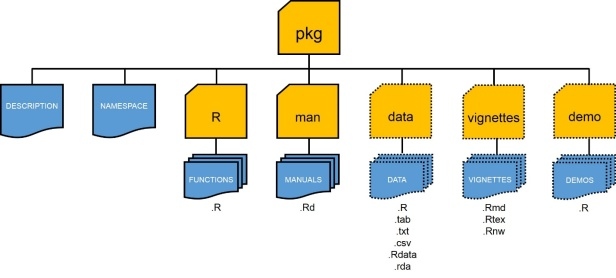

From [A Quickstart Guide for Building Your First R Package](https://methodsblog.com/2015/11/30/building-your-first-r-package/)

## Core components

- `DESCRIPTION` - file containing package metadata (e.g. package name, description, version, license, and author details). Also specifies package dependencies.
- `NAMESPACE` - details which functions and objects are exported by your package.
- `R/` - contains all R script files (`.R`) implementing package
- `man/` - contains all R documentation files (`.Rd`)

## Optional components

The following components are optional, but quite common:

- `tests/` - contains unit tests (`.R` scripts)
- `src/` - contains code to be compiled (usually C / C++)
- `data/` - contains example data sets (`.rds` or `.rda`)
- `inst/` - contains files that will be copied to the package’s top-level directory when it is installed (e.g. C/C++ headers, examples or data files that don’t belong in `data/`)
- `vignettes/` - contains long form documentation, can be static (`.pdf` or `.html`) or literate documents (e.g. `.qmd`, `.Rmd` or `.Rnw`)

## Package contents

Source Package

```r
fs::dir_tree("~/Desktop/Projects/diffmatchpatch/")
```

```
~/Desktop/Projects/diffmatchpatch/
├── DESCRIPTION
├── LICENSE.md
├── NAMESPACE
├── NEWS.md
├── R
│   ├── RcppExports.R
│   ├── diff.R
│   ├── diffmatchpatch-package.R
│   ├── match.R
│   ├── options.R
│   ├── patch.R
│   └── print.R
├── README.Rmd
├── README.md
├── cran-comments.md
├── diffmatchpatch.Rproj
├── inst
│   └── include
│       └── diff_match_patch.h
├── man
│   ├── diff.Rd
│   ├── dmp_options.Rd
│   ├── match.Rd
│   └── patch.Rd
└── src
    ├── Makevars
    ├── Makevars.win
    ├── RcppExports.cpp
    ├── RcppExports.o
    ├── common.h
    ├── diff.cpp
    ├── diff.o
    ├── diffmatchpatch.so
    ├── match.cpp
    ├── match.o
    ├── options.cpp
    ├── options.o
    ├── patch.cpp
    └── patch.o
```

Installed Package

```r
fs::dir_tree(system.file(package="diffmatchpatch"))
```

```
/Users/rundel/Library/R/arm64/4.5/library/diffmatchpatch
├── DESCRIPTION
├── INDEX
├── Meta
│   ├── Rd.rds
│   ├── features.rds
│   ├── hsearch.rds
│   ├── links.rds
│   ├── nsInfo.rds
│   └── package.rds
├── NAMESPACE
├── NEWS.md
├── R
│   ├── diffmatchpatch
│   ├── diffmatchpatch.rdb
│   └── diffmatchpatch.rdx
├── help
│   ├── AnIndex
│   ├── aliases.rds
│   ├── diffmatchpatch.rdb
│   ├── diffmatchpatch.rdx
│   └── paths.rds
├── html
│   ├── 00Index.html
│   └── R.css
├── include
│   └── diff_match_patch.h
└── libs
    └── diffmatchpatch.so
```

## Package Installation

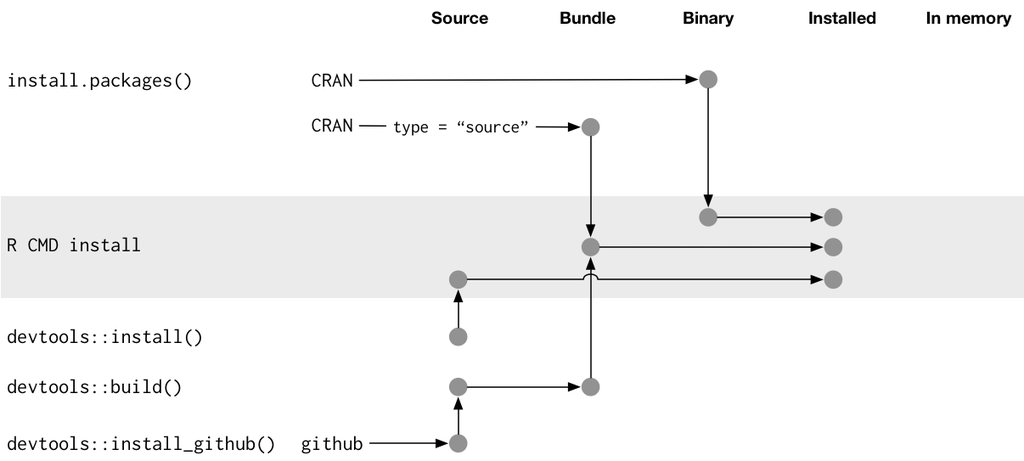

R Packages (1e) - Chap. 4

## Package Installation - Files

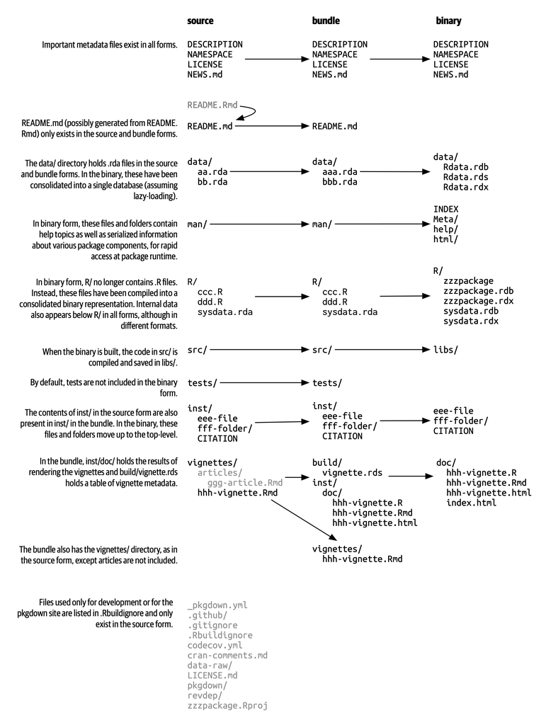

From [R Packages (2e) - Chap. 3.3](https://r-pkgs.org/structure.html#sec-bundled-package)

## Package development

What follows is an *opinionated* introduction to package development,

- this is not the only way to do things (none of the following tools are required)
- We strongly recommend using:
  - RStudio
  - RStudio projects
  - GitHub
  - usethis
  - roxygen2
- Read and follow along with R Packages (2e) - [Chapter 1 - “The Whole Game”](https://r-pkgs.org/whole-game.html)

[figure not shown]

## `usethis`

This is an immensely useful package for automating all kinds of routine (and tedious) tasks within R

- Tools for managing git and GitHub configuration
- Tools for managing collaboration on GitHub via pull requests (see `pr_*()`)
- Tools for creating and configuring packages
- Tools for configuring your R environment (e.g. `.Rprofile` and `.Renviron`)
- and much much more

# Live demo Building a Package

## Start your package

Rather than having to remember all of the necessary pieces and their format, `usethis` can help you bootstrap your package development process.

```r
usethis::create_package()
```

`available::available()` can be used to check if your proposed packagename is available.

## Choosing a license

An important early step in developing a package is choosing a license - this is not trivial but is important to do early on, particularly if collaborating with others.

There are many resources available to help you choose a license, including:

https://choosealicense.com/

## Documentation

All R packages are expected to have documentation for all *exported* functions and data sets (this is a CRAN requirement). This documentation is stored as `.Rd` files in the `man/` directory.

- The Rd format is a markup language that is loosely based on LaTeX
- Rd files are processed into LaTeX, HTML, and plain text when building the package
- All packages need Rd files, that doesn’t mean you need to write Rd

## Roxygen2

> The premise of roxygen2 is simple: describe your functions in comments next to their definitions and roxygen2 will process your source code and comments to automatically generate `.Rd` files in `man/`, `NAMESPACE`, and, if needed, the `Collate` field in `DESCRIPTION.`
- roxygen uses special comment lines prefixed with `#'`
- roxygen specific command have the format `@cmd` and mostly match `Rd` commands
- `devtools::document()` or menu `Build > Document` with reprocess all source files and rebuild all `Rd`s
- `usethis::create_package()` with `roxygen = TRUE` will initialize your package to use roxygen (default behavior)

# Other details

## Vignette

Long form documentation for your package that live in `vignettes/`, use `browseVignette(pkg)` to see a package’s vignettes.

- Not required, but adds a lot of value to a package
- Generally these are literate documents (`.Rmd`, `.Rnw`) that are compiled to `.html` or `.pdf` when the package is built.
- Built packages retain the rendered document, the source document, and all source code
  - `vignette("colwise", package = "dplyr")` opens rendered version
  - `edit(vignette("colwise", package = "dplyr"))` opens code chunks
- Use `usethis::use_vignette()` to create a RMarkdown vignette template

## Articles

These are an un-official extension to vignettes where package authors wish to include additional long form documentation that is included in their `pkgdown` site but not in the package (usually for space reasons).

- Use `usethis::use_article()` to create
- Files are added to `vignettes/articles/` which is added to `.Rbuildignore`

## Package data

Many packages contain sample data (e.g. `nycflights13`, `babynames`, etc.)

## Lazy data

By default when attaching a package all of that packages data is loaded - however if `LazyData: true` is set in the packages’ `DESCRIPTION` then data is only loaded when used.

```r
pryr::mem_used()
```

```
55.4 MB
```

```r
library(nycflights13)
pryr::mem_used()
```

```
55.7 MB
```

```r
invisible(flights)
pryr::mem_used()
```

```
96.3 MB
```

If you use `usethis::use_data()` this option will be set in `DESCRIPTION` automatically.

## Raw data

When published a package should generally only contain the final data set, but it is important that the process to generate the data is documented as well as any necessary preliminary data.

- These can live any where but the general suggestion is to create a `data-raw/` directory which is included in `.Rbuildignore`
- `data-raw/` then contain scripts, data files, and anything else needed to generate the final object
- See examples babynames or nycflights13
- Use `usethis::use_data_raw()` to create and ignore the `data-raw/` directory.

## Internal data

If you have data that you want to have access to from within the package but not exported then it needs to live in a special Rdata object located at `R/sysdata.rda`.

- Can be created using `usethis::use_data(obj1, obj2, internal = TRUE)`
- Each call to the above will overwrite, so needs to include all objects
- Not necessary for small data frames and similar objects - just create in a script. Use when you want the object to be compressed.
- Example [nflplotR](https://github.com/nflverse/nflplotR/tree/main/R) which contains team logos and colors for NFL teams.

## pkgdown

pkgdown is a package that makes it easy to build a website for your R package directly from the source files.

- Generates a polished website from your existing documentation
- Converts `man/` files to HTML reference pages
- Renders vignettes and articles as website pages
- Creates a searchable function reference
- Automatically links to other packages and functions
- Can be customized via a `_pkgdown.yml` file

```r
usethis::use_pkgdown()
pkgdown::build_site()
```

See the [pkgdown documentation](https://pkgdown.r-lib.org/) for more details.